# Risk Factor Analysis

## Outcome Variable

**Outcome Variable:** y_rate_haz

## Predictor Variables

**Intervention Variable:** predexfd6

**Adjustment Set:**

unadjusted

## Stratifying Variables

The analysis was stratified on these variable(s):

- agecat
- studyid
- country

## Data Summary

| agecat | studyid | country | predexfd6 | n_cell | n |
| --- | --- | --- | --- | --- | --- |
| 0-3 months | ki0047075b-MAL-ED | BANGLADESH | 0 | 112 | 233 |
| 0-3 months | ki0047075b-MAL-ED | BANGLADESH | 1 | 121 | 233 |
| 0-3 months | ki1017093b-PROVIDE | BANGLADESH | 0 | 467 | 634 |
| 0-3 months | ki1017093b-PROVIDE | BANGLADESH | 1 | 167 | 634 |
| 0-3 months | kiGH5241-JiVitA-3 | BANGLADESH | 0 | 4338 | 20039 |
| 0-3 months | kiGH5241-JiVitA-3 | BANGLADESH | 1 | 15701 | 20039 |
| 0-3 months | kiGH5241-JiVitA-4 | BANGLADESH | 0 | 293 | 1805 |
| 0-3 months | kiGH5241-JiVitA-4 | BANGLADESH | 1 | 1512 | 1805 |
| 0-3 months | ki0047075b-MAL-ED | BRAZIL | 0 | 148 | 175 |
| 0-3 months | ki0047075b-MAL-ED | BRAZIL | 1 | 27 | 175 |
| 0-3 months | ki1101329-Keneba | GAMBIA | 0 | 816 | 1207 |
| 0-3 months | ki1101329-Keneba | GAMBIA | 1 | 391 | 1207 |
| 0-3 months | ki0047075b-MAL-ED | INDIA | 0 | 178 | 193 |
| 0-3 months | ki0047075b-MAL-ED | INDIA | 1 | 15 | 193 |
| 0-3 months | ki1000108-CMC-V-BCS-2002 | INDIA | 1 | 6 | 6 |
| 0-3 months | ki1000108-IRC | INDIA | 0 | 14 | 14 |
| 0-3 months | ki1000304b-SAS-CompFeed | INDIA | 0 | 19 | 398 |
| 0-3 months | ki1000304b-SAS-CompFeed | INDIA | 1 | 379 | 398 |
| 0-3 months | ki0047075b-MAL-ED | NEPAL | 0 | 150 | 173 |
| 0-3 months | ki0047075b-MAL-ED | NEPAL | 1 | 23 | 173 |
| 0-3 months | ki1000109-EE | PAKISTAN | 0 | 130 | 297 |
| 0-3 months | ki1000109-EE | PAKISTAN | 1 | 167 | 297 |
| 0-3 months | ki0047075b-MAL-ED | PERU | 0 | 150 | 258 |
| 0-3 months | ki0047075b-MAL-ED | PERU | 1 | 108 | 258 |
| 0-3 months | ki0047075b-MAL-ED | SOUTH AFRICA | 0 | 206 | 209 |
| 0-3 months | ki0047075b-MAL-ED | SOUTH AFRICA | 1 | 3 | 209 |
| 0-3 months | ki0047075b-MAL-ED | TANZANIA, UNITED REPUBLIC OF | 0 | 223 | 224 |
| 0-3 months | ki0047075b-MAL-ED | TANZANIA, UNITED REPUBLIC OF | 1 | 1 | 224 |
| 3-6 months | ki0047075b-MAL-ED | BANGLADESH | 0 | 108 | 225 |
| 3-6 months | ki0047075b-MAL-ED | BANGLADESH | 1 | 117 | 225 |

[output cut: 89 more lines]

The following strata were considered:

- agecat: 0-3 months, studyid: ki0047075b-MAL-ED, country: BANGLADESH
- agecat: 0-3 months, studyid: ki0047075b-MAL-ED, country: BRAZIL
- agecat: 0-3 months, studyid: ki0047075b-MAL-ED, country: INDIA
- agecat: 0-3 months, studyid: ki0047075b-MAL-ED, country: NEPAL
- agecat: 0-3 months, studyid: ki0047075b-MAL-ED, country: PERU
- agecat: 0-3 months, studyid: ki0047075b-MAL-ED, country: SOUTH AFRICA
- agecat: 0-3 months, studyid: ki0047075b-MAL-ED, country: TANZANIA, UNITED REPUBLIC OF
- agecat: 0-3 months, studyid: ki1000108-CMC-V-BCS-2002, country: INDIA
- agecat: 0-3 months, studyid: ki1000108-IRC, country: INDIA
- agecat: 0-3 months, studyid: ki1000109-EE, country: PAKISTAN
- agecat: 0-3 months, studyid: ki1000304b-SAS-CompFeed, country: INDIA
- agecat: 0-3 months, studyid: ki1017093b-PROVIDE, country: BANGLADESH
- agecat: 0-3 months, studyid: ki1101329-Keneba, country: GAMBIA
- agecat: 0-3 months, studyid: kiGH5241-JiVitA-3, country: BANGLADESH
- agecat: 0-3 months, studyid: kiGH5241-JiVitA-4, country: BANGLADESH
- agecat: 12-24 months, studyid: ki0047075b-MAL-ED, country: BANGLADESH
- agecat: 12-24 months, studyid: ki0047075b-MAL-ED, country: BRAZIL
- agecat: 12-24 months, studyid: ki0047075b-MAL-ED, country: INDIA
- agecat: 12-24 months, studyid: ki0047075b-MAL-ED, country: NEPAL
- agecat: 12-24 months, studyid: ki0047075b-MAL-ED, country: PERU
- agecat: 12-24 months, studyid: ki0047075b-MAL-ED, country: SOUTH AFRICA
- agecat: 12-24 months, studyid: ki0047075b-MAL-ED, country: TANZANIA, UNITED REPUBLIC OF
- agecat: 12-24 months, studyid: ki1000108-CMC-V-BCS-2002, country: INDIA
- agecat: 12-24 months, studyid: ki1000108-IRC, country: INDIA
- agecat: 12-24 months, studyid: ki1017093b-PROVIDE, country: BANGLADESH
- agecat: 12-24 months, studyid: ki1101329-Keneba, country: GAMBIA
- agecat: 12-24 months, studyid: ki1113344-GMS-Nepal, country: NEPAL
- agecat: 12-24 months, studyid: ki1148112-LCNI-5, country: MALAWI
- agecat: 12-24 months, studyid: kiGH5241-JiVitA-3, country: BANGLADESH
- agecat: 12-24 months, studyid: kiGH5241-JiVitA-4, country: BANGLADESH
- agecat: 3-6 months, studyid: ki0047075b-MAL-ED, country: BANGLADESH
- agecat: 3-6 months, studyid: ki0047075b-MAL-ED, country: BRAZIL
- agecat: 3-6 months, studyid: ki0047075b-MAL-ED, country: INDIA
- agecat: 3-6 months, studyid: ki0047075b-MAL-ED, country: NEPAL
- agecat: 3-6 months, studyid: ki0047075b-MAL-ED, country: PERU
- agecat: 3-6 months, studyid: ki0047075b-MAL-ED, country: SOUTH AFRICA
- agecat: 3-6 months, studyid: ki0047075b-MAL-ED, country: TANZANIA, UNITED REPUBLIC OF
- agecat: 3-6 months, studyid: ki1000108-CMC-V-BCS-2002, country: INDIA
- agecat: 3-6 months, studyid: ki1000108-IRC, country: INDIA
- agecat: 3-6 months, studyid: ki1000109-EE, country: PAKISTAN
- agecat: 3-6 months, studyid: ki1000304b-SAS-CompFeed, country: INDIA
- agecat: 3-6 months, studyid: ki1017093b-PROVIDE, country: BANGLADESH
- agecat: 3-6 months, studyid: ki1101329-Keneba, country: GAMBIA
- agecat: 3-6 months, studyid: ki1113344-GMS-Nepal, country: NEPAL
- agecat: 3-6 months, studyid: kiGH5241-JiVitA-3, country: BANGLADESH
- agecat: 3-6 months, studyid: kiGH5241-JiVitA-4, country: BANGLADESH
- agecat: 6-12 months, studyid: ki0047075b-MAL-ED, country: BANGLADESH
- agecat: 6-12 months, studyid: ki0047075b-MAL-ED, country: BRAZIL
- agecat: 6-12 months, studyid: ki0047075b-MAL-ED, country: INDIA
- agecat: 6-12 months, studyid: ki0047075b-MAL-ED, country: NEPAL
- agecat: 6-12 months, studyid: ki0047075b-MAL-ED, country: PERU
- agecat: 6-12 months, studyid: ki0047075b-MAL-ED, country: SOUTH AFRICA
- agecat: 6-12 months, studyid: ki0047075b-MAL-ED, country: TANZANIA, UNITED REPUBLIC OF
- agecat: 6-12 months, studyid: ki1000108-CMC-V-BCS-2002, country: INDIA
- agecat: 6-12 months, studyid: ki1000108-IRC, country: INDIA
- agecat: 6-12 months, studyid: ki1000109-EE, country: PAKISTAN
- agecat: 6-12 months, studyid: ki1000304b-SAS-CompFeed, country: INDIA
- agecat: 6-12 months, studyid: ki1000304b-SAS-FoodSuppl, country: INDIA
- agecat: 6-12 months, studyid: ki1017093b-PROVIDE, country: BANGLADESH
- agecat: 6-12 months, studyid: ki1101329-Keneba, country: GAMBIA
- agecat: 6-12 months, studyid: ki1113344-GMS-Nepal, country: NEPAL
- agecat: 6-12 months, studyid: ki1148112-LCNI-5, country: MALAWI
- agecat: 6-12 months, studyid: kiGH5241-JiVitA-3, country: BANGLADESH
- agecat: 6-12 months, studyid: kiGH5241-JiVitA-4, country: BANGLADESH

### Dropped Strata

Some strata were dropped due to rare outcomes:

- agecat: 0-3 months, studyid: ki0047075b-MAL-ED, country: SOUTH AFRICA
- agecat: 0-3 months, studyid: ki0047075b-MAL-ED, country: TANZANIA, UNITED REPUBLIC OF
- agecat: 3-6 months, studyid: ki0047075b-MAL-ED, country: SOUTH AFRICA
- agecat: 3-6 months, studyid: ki0047075b-MAL-ED, country: TANZANIA, UNITED REPUBLIC OF
- agecat: 6-12 months, studyid: ki1000109-EE, country: PAKISTAN
- agecat: 6-12 months, studyid: ki0047075b-MAL-ED, country: SOUTH AFRICA
- agecat: 6-12 months, studyid: ki0047075b-MAL-ED, country: TANZANIA, UNITED REPUBLIC OF
- agecat: 12-24 months, studyid: ki0047075b-MAL-ED, country: SOUTH AFRICA
- agecat: 12-24 months, studyid: ki0047075b-MAL-ED, country: TANZANIA, UNITED REPUBLIC OF

## Methods Detail

We’re interested in the causal parameters $E[Y_a]$ for all values of $a \in \mathcal{A}$. These parameters represent the mean outcome if, possibly contrary to fact, we intervened to set all units to have $A=a$. Under the randomization and positivity assumptions, these are identified by the statistical parameters $\psi_a=E_W[E_{Y|A,W}(Y|A=a,W)]$. In addition, we’re interested in the mean of $Y$, $E[Y]$ under no intervention (the observed mean). We will estimate these parameters by using SuperLearner to fit the relevant likelihood factors – $E_{Y|A,W}(Y|A=a,W)$ and $p(A=a|W)$, and then updating our likelihood fit using a joint TMLE.

For unadjusted analyses ($W=\{\}$), initial likelihoods were estimated using Lrnr_glm to estimate the simple $E(Y|A)$ and Lrnr_mean to estimate $p(A)$. For adjusted analyses, a small library containing Lrnr_glmnet, Lrnr_xgboost, and Lrnr_mean was used.

Having estimated these parameters, we will then use the delta method to estimate relative risks and attributable risks relative to a prespecified baseline level of $A$.

[output not shown]

[output cut: 269 more lines]

[output not shown]

# Results Detail

## Results Plots

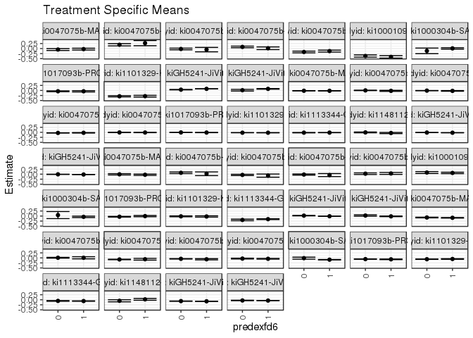

[figure not shown]

## Results Table

### Parameter: TSM

| agecat | studyid | country | intervention_level | baseline_level | estimate | ci_lower | ci_upper |
| --- | --- | --- | --- | --- | --- | --- | --- |
| 0-3 months | ki0047075b-MAL-ED | BANGLADESH | 0 | NA | -0.0476565 | -0.0950372 | -0.0002758 |
| 0-3 months | ki0047075b-MAL-ED | BANGLADESH | 1 | NA | -0.0267509 | -0.0712627 | 0.0177609 |
| 0-3 months | ki0047075b-MAL-ED | BRAZIL | 0 | NA | 0.1899384 | 0.1331176 | 0.2467593 |
| 0-3 months | ki0047075b-MAL-ED | BRAZIL | 1 | NA | 0.2710311 | 0.1415500 | 0.4005122 |
| 0-3 months | ki0047075b-MAL-ED | INDIA | 0 | NA | -0.0197838 | -0.0607732 | 0.0212055 |
| 0-3 months | ki0047075b-MAL-ED | INDIA | 1 | NA | -0.0518390 | -0.1615837 | 0.0579057 |
| 0-3 months | ki0047075b-MAL-ED | NEPAL | 0 | NA | 0.0823695 | 0.0429595 | 0.1217794 |
| 0-3 months | ki0047075b-MAL-ED | NEPAL | 1 | NA | 0.0159974 | -0.0501167 | 0.0821114 |
| 0-3 months | ki0047075b-MAL-ED | PERU | 0 | NA | -0.1691767 | -0.2115418 | -0.1268117 |
| 0-3 months | ki0047075b-MAL-ED | PERU | 1 | NA | -0.1254340 | -0.1747977 | -0.0760704 |
| 0-3 months | ki1000109-EE | PAKISTAN | 0 | NA | -0.3700656 | -0.4267848 | -0.3133464 |
| 0-3 months | ki1000109-EE | PAKISTAN | 1 | NA | -0.4123678 | -0.4738081 | -0.3509274 |
| 0-3 months | ki1000304b-SAS-CompFeed | INDIA | 0 | NA | -0.1129364 | -0.2527497 | 0.0268769 |
| 0-3 months | ki1000304b-SAS-CompFeed | INDIA | 1 | NA | 0.0096915 | -0.0260235 | 0.0454064 |
| 0-3 months | ki1017093b-PROVIDE | BANGLADESH | 0 | NA | -0.0413719 | -0.0631878 | -0.0195560 |
| 0-3 months | ki1017093b-PROVIDE | BANGLADESH | 1 | NA | -0.0411532 | -0.0732021 | -0.0091043 |
| 0-3 months | ki1101329-Keneba | GAMBIA | 0 | NA | -0.2895392 | -0.3202600 | -0.2588183 |
| 0-3 months | ki1101329-Keneba | GAMBIA | 1 | NA | -0.2851488 | -0.3281926 | -0.2421050 |
| 0-3 months | kiGH5241-JiVitA-3 | BANGLADESH | 0 | NA | 0.0379405 | 0.0280783 | 0.0478026 |
| 0-3 months | kiGH5241-JiVitA-3 | BANGLADESH | 1 | NA | 0.0795754 | 0.0742225 | 0.0849282 |
| 0-3 months | kiGH5241-JiVitA-4 | BANGLADESH | 0 | NA | 0.0120474 | -0.0293004 | 0.0533952 |
| 0-3 months | kiGH5241-JiVitA-4 | BANGLADESH | 1 | NA | 0.0782100 | 0.0624297 | 0.0939903 |
| 3-6 months | ki0047075b-MAL-ED | BANGLADESH | 0 | NA | -0.0071456 | -0.0404687 | 0.0261776 |
| 3-6 months | ki0047075b-MAL-ED | BANGLADESH | 1 | NA | -0.0296737 | -0.0623525 | 0.0030051 |
| 3-6 months | ki0047075b-MAL-ED | BRAZIL | 0 | NA | 0.0686947 | 0.0289451 | 0.1084443 |
| 3-6 months | ki0047075b-MAL-ED | BRAZIL | 1 | NA | 0.0199377 | -0.0710783 | 0.1109537 |
| 3-6 months | ki0047075b-MAL-ED | INDIA | 0 | NA | -0.0373705 | -0.0678959 | -0.0068452 |
| 3-6 months | ki0047075b-MAL-ED | INDIA | 1 | NA | -0.0729375 | -0.1514603 | 0.0055853 |
| 3-6 months | ki0047075b-MAL-ED | NEPAL | 0 | NA | -0.0186830 | -0.0471850 | 0.0098189 |
| 3-6 months | ki0047075b-MAL-ED | NEPAL | 1 | NA | -0.0447744 | -0.1204223 | 0.0308736 |

[output cut: 62 more lines]

### Parameter: E(Y)

| agecat | studyid | country | intervention_level | baseline_level | estimate | ci_lower | ci_upper |
| --- | --- | --- | --- | --- | --- | --- | --- |
| 0-3 months | ki0047075b-MAL-ED | BANGLADESH | NA | NA | -0.0367999 | -0.0692784 | -0.0043215 |
| 0-3 months | ki0047075b-MAL-ED | BRAZIL | NA | NA | 0.2024499 | 0.1502269 | 0.2546728 |
| 0-3 months | ki0047075b-MAL-ED | INDIA | NA | NA | -0.0222752 | -0.0610481 | 0.0164977 |
| 0-3 months | ki0047075b-MAL-ED | NEPAL | NA | NA | 0.0735454 | 0.0381022 | 0.1089887 |
| 0-3 months | ki0047075b-MAL-ED | PERU | NA | NA | -0.1508658 | -0.1831247 | -0.1186070 |
| 0-3 months | ki1000109-EE | PAKISTAN | NA | NA | -0.3938516 | -0.4364614 | -0.3512419 |
| 0-3 months | ki1000304b-SAS-CompFeed | INDIA | NA | NA | 0.0038374 | -0.0265594 | 0.0342341 |
| 0-3 months | ki1017093b-PROVIDE | BANGLADESH | NA | NA | -0.0413143 | -0.0594662 | -0.0231624 |
| 0-3 months | ki1101329-Keneba | GAMBIA | NA | NA | -0.2881169 | -0.3131328 | -0.2631010 |
| 0-3 months | kiGH5241-JiVitA-3 | BANGLADESH | NA | NA | 0.0705623 | 0.0656085 | 0.0755161 |
| 0-3 months | kiGH5241-JiVitA-4 | BANGLADESH | NA | NA | 0.0674700 | 0.0524969 | 0.0824432 |
| 3-6 months | ki0047075b-MAL-ED | BANGLADESH | NA | NA | -0.0188602 | -0.0422435 | 0.0045231 |
| 3-6 months | ki0047075b-MAL-ED | BRAZIL | NA | NA | 0.0604904 | 0.0239698 | 0.0970111 |
| 3-6 months | ki0047075b-MAL-ED | INDIA | NA | NA | -0.0402159 | -0.0690209 | -0.0114109 |
| 3-6 months | ki0047075b-MAL-ED | NEPAL | NA | NA | -0.0217195 | -0.0484207 | 0.0049817 |
| 3-6 months | ki0047075b-MAL-ED | PERU | NA | NA | 0.0285063 | -0.0025558 | 0.0595685 |
| 3-6 months | ki1000109-EE | PAKISTAN | NA | NA | 0.0701161 | 0.0419135 | 0.0983187 |
| 3-6 months | ki1000304b-SAS-CompFeed | INDIA | NA | NA | -0.0357951 | -0.0659472 | -0.0056430 |
| 3-6 months | ki1017093b-PROVIDE | BANGLADESH | NA | NA | -0.0272428 | -0.0436954 | -0.0107902 |
| 3-6 months | ki1101329-Keneba | GAMBIA | NA | NA | -0.0174002 | -0.0363928 | 0.0015925 |
| 3-6 months | ki1113344-GMS-Nepal | NEPAL | NA | NA | -0.1663669 | -0.1850409 | -0.1476929 |
| 3-6 months | kiGH5241-JiVitA-3 | BANGLADESH | NA | NA | -0.0035176 | -0.0083841 | 0.0013489 |
| 3-6 months | kiGH5241-JiVitA-4 | BANGLADESH | NA | NA | -0.0095967 | -0.0234440 | 0.0042506 |
| 6-12 months | ki0047075b-MAL-ED | BANGLADESH | NA | NA | -0.0810302 | -0.0916713 | -0.0703891 |
| 6-12 months | ki0047075b-MAL-ED | BRAZIL | NA | NA | 0.0065644 | -0.0129183 | 0.0260472 |
| 6-12 months | ki0047075b-MAL-ED | INDIA | NA | NA | -0.0775092 | -0.0898591 | -0.0651592 |
| 6-12 months | ki0047075b-MAL-ED | NEPAL | NA | NA | -0.0484306 | -0.0591023 | -0.0377589 |
| 6-12 months | ki0047075b-MAL-ED | PERU | NA | NA | -0.0382822 | -0.0523761 | -0.0241883 |
| 6-12 months | ki1000304b-SAS-CompFeed | INDIA | NA | NA | -0.0862948 | -0.0967898 | -0.0757998 |
| 6-12 months | ki1017093b-PROVIDE | BANGLADESH | NA | NA | -0.0626151 | -0.0695574 | -0.0556729 |
| 6-12 months | ki1101329-Keneba | GAMBIA | NA | NA | -0.0621235 | -0.0700857 | -0.0541612 |
| 6-12 months | ki1113344-GMS-Nepal | NEPAL | NA | NA | -0.0623284 | -0.0705747 | -0.0540821 |
| 6-12 months | ki1148112-LCNI-5 | MALAWI | NA | NA | -0.0281085 | -0.0675243 | 0.0113073 |
| 6-12 months | kiGH5241-JiVitA-3 | BANGLADESH | NA | NA | -0.0749683 | -0.0778180 | -0.0721186 |
| 6-12 months | kiGH5241-JiVitA-4 | BANGLADESH | NA | NA | -0.0387665 | -0.0435189 | -0.0340140 |
| 12-24 months | ki0047075b-MAL-ED | BANGLADESH | NA | NA | -0.0177288 | -0.0232009 | -0.0122567 |
| 12-24 months | ki0047075b-MAL-ED | BRAZIL | NA | NA | -0.0013016 | -0.0119070 | 0.0093038 |
| 12-24 months | ki0047075b-MAL-ED | INDIA | NA | NA | -0.0099239 | -0.0151132 | -0.0047346 |
| 12-24 months | ki0047075b-MAL-ED | NEPAL | NA | NA | -0.0297758 | -0.0348315 | -0.0247201 |
| 12-24 months | ki0047075b-MAL-ED | PERU | NA | NA | -0.0082368 | -0.0151828 | -0.0012908 |
| 12-24 months | ki1017093b-PROVIDE | BANGLADESH | NA | NA | -0.0081718 | -0.0120131 | -0.0043304 |
| 12-24 months | ki1101329-Keneba | GAMBIA | NA | NA | -0.0199103 | -0.0237186 | -0.0161020 |
| 12-24 months | ki1113344-GMS-Nepal | NEPAL | NA | NA | -0.0159785 | -0.0210905 | -0.0108666 |
| 12-24 months | ki1148112-LCNI-5 | MALAWI | NA | NA | -0.0140852 | -0.0319419 | 0.0037715 |
| 12-24 months | kiGH5241-JiVitA-3 | BANGLADESH | NA | NA | -0.0189940 | -0.0208299 | -0.0171580 |
| 12-24 months | kiGH5241-JiVitA-4 | BANGLADESH | NA | NA | -0.0145458 | -0.0165637 | -0.0125280 |

### Parameter: ATE

| agecat | studyid | country | intervention_level | baseline_level | estimate | ci_lower | ci_upper |
| --- | --- | --- | --- | --- | --- | --- | --- |
| 0-3 months | ki0047075b-MAL-ED | BANGLADESH | 0 | 0 | 0.0000000 | 0.0000000 | 0.0000000 |
| 0-3 months | ki0047075b-MAL-ED | BANGLADESH | 1 | 0 | 0.0209056 | -0.0441039 | 0.0859150 |
| 0-3 months | ki0047075b-MAL-ED | BRAZIL | 0 | 0 | 0.0000000 | 0.0000000 | 0.0000000 |
| 0-3 months | ki0047075b-MAL-ED | BRAZIL | 1 | 0 | 0.0810927 | -0.0603074 | 0.2224927 |
| 0-3 months | ki0047075b-MAL-ED | INDIA | 0 | 0 | 0.0000000 | 0.0000000 | 0.0000000 |
| 0-3 months | ki0047075b-MAL-ED | INDIA | 1 | 0 | -0.0320551 | -0.1492047 | 0.0850944 |
| 0-3 months | ki0047075b-MAL-ED | NEPAL | 0 | 0 | 0.0000000 | 0.0000000 | 0.0000000 |
| 0-3 months | ki0047075b-MAL-ED | NEPAL | 1 | 0 | -0.0663721 | -0.1433410 | 0.0105968 |
| 0-3 months | ki0047075b-MAL-ED | PERU | 0 | 0 | 0.0000000 | 0.0000000 | 0.0000000 |
| 0-3 months | ki0047075b-MAL-ED | PERU | 1 | 0 | 0.0437427 | -0.0213078 | 0.1087932 |
| 0-3 months | ki1000109-EE | PAKISTAN | 0 | 0 | 0.0000000 | 0.0000000 | 0.0000000 |
| 0-3 months | ki1000109-EE | PAKISTAN | 1 | 0 | -0.0423022 | -0.1259203 | 0.0413159 |
| 0-3 months | ki1000304b-SAS-CompFeed | INDIA | 0 | 0 | 0.0000000 | 0.0000000 | 0.0000000 |
| 0-3 months | ki1000304b-SAS-CompFeed | INDIA | 1 | 0 | 0.1226279 | -0.0401773 | 0.2854331 |
| 0-3 months | ki1017093b-PROVIDE | BANGLADESH | 0 | 0 | 0.0000000 | 0.0000000 | 0.0000000 |
| 0-3 months | ki1017093b-PROVIDE | BANGLADESH | 1 | 0 | 0.0002187 | -0.0385506 | 0.0389881 |
| 0-3 months | ki1101329-Keneba | GAMBIA | 0 | 0 | 0.0000000 | 0.0000000 | 0.0000000 |
| 0-3 months | ki1101329-Keneba | GAMBIA | 1 | 0 | 0.0043903 | -0.0484920 | 0.0572727 |
| 0-3 months | kiGH5241-JiVitA-3 | BANGLADESH | 0 | 0 | 0.0000000 | 0.0000000 | 0.0000000 |
| 0-3 months | kiGH5241-JiVitA-3 | BANGLADESH | 1 | 0 | 0.0416349 | 0.0310683 | 0.0522014 |
| 0-3 months | kiGH5241-JiVitA-4 | BANGLADESH | 0 | 0 | 0.0000000 | 0.0000000 | 0.0000000 |
| 0-3 months | kiGH5241-JiVitA-4 | BANGLADESH | 1 | 0 | 0.0661626 | 0.0219979 | 0.1103273 |
| 3-6 months | ki0047075b-MAL-ED | BANGLADESH | 0 | 0 | 0.0000000 | 0.0000000 | 0.0000000 |
| 3-6 months | ki0047075b-MAL-ED | BANGLADESH | 1 | 0 | -0.0225281 | -0.0692008 | 0.0241445 |
| 3-6 months | ki0047075b-MAL-ED | BRAZIL | 0 | 0 | 0.0000000 | 0.0000000 | 0.0000000 |
| 3-6 months | ki0047075b-MAL-ED | BRAZIL | 1 | 0 | -0.0487570 | -0.1480744 | 0.0505604 |
| 3-6 months | ki0047075b-MAL-ED | INDIA | 0 | 0 | 0.0000000 | 0.0000000 | 0.0000000 |
| 3-6 months | ki0047075b-MAL-ED | INDIA | 1 | 0 | -0.0355669 | -0.1198143 | 0.0486805 |
| 3-6 months | ki0047075b-MAL-ED | NEPAL | 0 | 0 | 0.0000000 | 0.0000000 | 0.0000000 |
| 3-6 months | ki0047075b-MAL-ED | NEPAL | 1 | 0 | -0.0260913 | -0.1069305 | 0.0547478 |

[output cut: 62 more lines]